# Ejercicios manejo - parte 2

Elena Quintero

2025-02-20

## El dataset

El fichero que vamos a utilizar procede del datapaper de **Nigro et al. 2025 Ecology**. Este dataset recoge información de datos de producion de frutos (`count`) y diámetro (`dbh`) de 141 especies de plantas leñosas en 9 zonas LTER (`site_name`) de Estados Unidos, entre los años 1957 and 2021, basado en trampas de semillas o recuentos de semillas y/o conos en árboles individuales.

Nigro, K. M., Barton, J. H., Macias, D., Chaudhary, V. B., Pearse, I. S., Bell, D. M., Chen, A., Cleavitt, N. L., Crone, E. E., Greene, D. F., Holland, E. P., Johnstone, J. F., Koenig, W. D., Lyon, N. J., Miller, T. E. X., Schulze, M., Snell, R. S., Zimmerman, J. K., Knops, J. M. H., … Redmond, M. D. (2025). Co-mast: Harmonized seed production data for woody plants across US long-term research sites. Ecology, n/a(n/a), e4463. https://doi.org/10.1002/ecy.4463

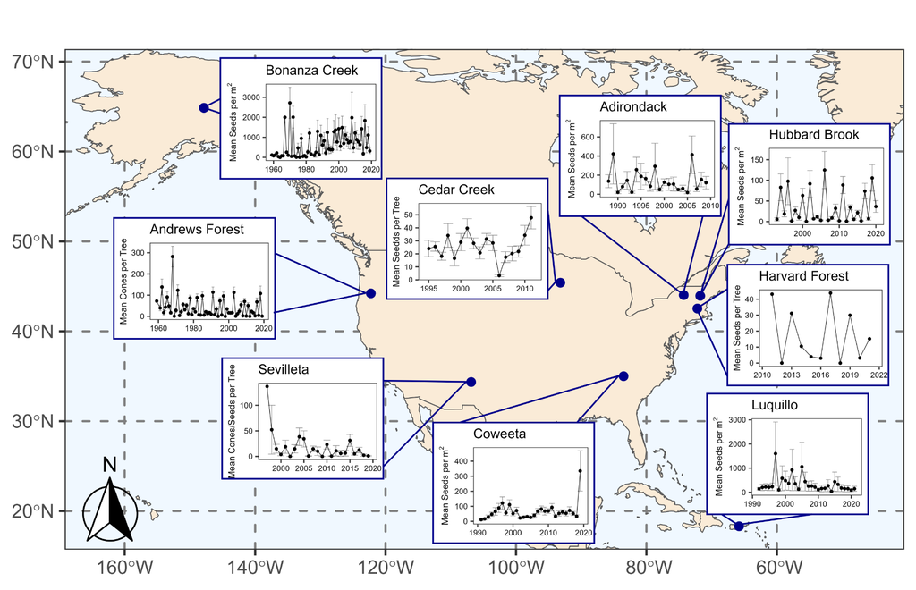

### Cargar datos

Quitar todas las observaciones de 0 frutos o NA - crear dataset para ejercicios (dt_ej)

```r
dt_raw <- read_csv("files/seeds.csv")

dt_ej <- dt_raw |> filter(count != 0)
```

## Ejercicio 1

Usando la base de datos (dt_ej) crear una nueva variable que sea el logaritmo de los frutos (funcion `log()` y ordenar de mayor a menor.

```r
dt_ej |>
  mutate(fruit_log = log(count)) |>
  arrange(desc(fruit_log)) |>
  select(site_name, species_name, fruit_log)
```

```
## # A tibble: 82,281 × 3
##    site_name species_name          fruit_log
##    <chr>     <chr>                     <dbl>
##  1 LUQ       Cecropia_schreberiana      13.9
##  2 LUQ       Ficus_trigonata            11.6
##  3 LUQ       Ficus_trigonata            11.1
##  4 LUQ       Ficus_trigonata            10.7
##  5 LUQ       Ficus_trigonata            10.6
##  6 LUQ       Ficus_trigonata            10.5
##  7 LUQ       Ficus_trigonata            10.4
##  8 LUQ       Ficus_trigonata            10.4
##  9 LUQ       Ficus_trigonata            10.4
## 10 LUQ       Cecropia_schreberiana      10.3
## # ℹ 82,271 more rows
```

## Ejercicio 2

Usando la base de datos (dt_ej) crear una nueva variable llamada “periodo” que separe “antes” y “despues” del año 2000.

```r
dt_ej |>
  mutate(periodo = if_else(year < 2000, "antes", "despues")) |>
  select(site_name, year, periodo)
```

```
## # A tibble: 82,281 × 3
##    site_name  year periodo
##    <chr>     <dbl> <chr>
##  1 AND        1962 antes
##  2 AND        1965 antes
##  3 AND        1967 antes
##  4 AND        1968 antes
##  5 AND        1971 antes
##  6 AND        1974 antes
##  7 AND        1976 antes
##  8 AND        1978 antes
##  9 AND        1979 antes
## 10 AND        1980 antes
## # ℹ 82,271 more rows
```

## Ejercicio 3

```r
dt_ej |>
  filter(general_method == "TRAP") |>
  group_by(site_name) |>
  summarise(max_fruit = max(count),
            min_fruit = mean(count))
```

```
## # A tibble: 5 × 3
##   site_name max_fruit min_fruit
##   <chr>         <dbl>     <dbl>
## 1 AEC             591     21.5
## 2 BNZ            7230    272.
## 3 CWT            1383     22.3
## 4 HBR             244      9.34
## 5 LUQ         1114340    133.
```

## Ejercicio 4

Usando la base de datos (dt_ej), quedarnos sólo con el sitio “AND” y con datos de diametro mayor que 0, y calcular diámetro medio y SD para cada especie de árbol (`species_name`).

```r
dt_ej |>
  filter(site_name == "AND") |>
  filter(stem_diameter_cm != 0) |>
  group_by(species_name) |>
  summarise(diam = mean(stem_diameter_cm),
            diam_sd = sd(stem_diameter_cm))
```

```
## # A tibble: 10 × 3
##    species_name       diam diam_sd
##    <chr>             <dbl>   <dbl>
##  1 Abies_amabilis     65.0    19.7
##  2 Abies_concolor     63.1    18.6
##  3 Abies_grandis      74.5    14.8
##  4 Abies_lasiocarpa   45.0    16.2
##  5 Abies_magnifica    87.9    19.9
##  6 Abies_procera     104.     34.4
##  7 Picea_engelmannii  80.2    16.5
##  8 Pinus_lambertiana 114.     27.7
##  9 Pinus_monticola    63.4    22.4
## 10 Tsuga_mertensiana  56.5    12.5
```

## Ejercicio 5

Usando la base de datos (dt_ej), calcular el número de árboles mayores de 40cm de diámetro y menores de 40cm de diámetro.

```r
dt_ej |>
  filter(stem_diameter_cm != 0) |>
  mutate(tree_size = if_else(stem_diameter_cm >= 40, "big", "small")) |>
  group_by(tree_size) |>
  summarise(n_trees = n())
```

```
## # A tibble: 2 × 2
##   tree_size n_trees
##   <chr>       <int>
## 1 big          1405
## 2 small          98
```

# Combinar dataset

Crear una nueva base de datos de ejercicios

```r
sp_info <- read_csv("files/species_attributes.csv")
dt_ej2 <- dt_ej |>
  left_join(sp_info, by = c("species_name"))
```

## Ejercicio 6

Con el nuevo dataset (dt_ej2) contar numero medio de frutos para los distintos tipos de micorrizas (`mycorrhiza_type`)

```r
dt_ej2 |>
  group_by(mycorrhiza_type) |>
  summarise(fruits = mean(count))
```

```
## # A tibble: 5 × 2
##   mycorrhiza_type fruits
##   <chr>            <dbl>
## 1 AM               98.0
## 2 EM               84.5
## 3 None              2.86
## 4 ericoid          24.7
## 5 <NA>             12.6
```

## Ejercicio 7

Con el nuevo dataset (dt_ej2) calcular numero máximo de frutos para los distintos tipos de tolerancia a la sombra (`shade_tolerance`) y crear una tabla donde las columnas sean los tipos de tolerancia y las filas sean el numero maximo de frutos en cada sitio

```r
dt_ej2 |>
  group_by(site_name, shade_tolerance) |>
  summarise(max_fruit = max(count)) |>
  pivot_wider(names_from = shade_tolerance,
              values_from = max_fruit)
```

```
## # A tibble: 9 × 5
## # Groups:   site_name [9]
##   site_name intermediate tolerant  `NA` intolerant
##   <chr>            <dbl>    <dbl> <dbl>      <dbl>
## 1 AEC                591      282    53         NA
## 2 AND                510     5000    NA       2000
## 3 BNZ               4018     7230    NA       6379
## 4 CDR                142       NA    NA        151
## 5 CWT                630     1383    27        516
## 6 HBR                 30      244    NA         NA
## 7 HFR                 NA       77    NA         NA
## 8 LUQ             106650      890  1020    1114340
## 9 SEV                 73       NA    NA       1100
```